# Retail Store Performance Analysis Diagnosing What Drives Sales, Marketing Efficiency, and Profit Margin Across Store Types and Regions

## Project Description

A retail business operating 150 stores across four regions — North, South, East, and West — needed to understand why performance varied significantly across its Mall, Standalone, and Online store formats. Despite similar product offerings, stores showed wide gaps in monthly sales, profit margins, and marketing returns with no clear explanation.

This analysis applies a full three-layer analytical framework across 10 business variables to identify the root causes of performance gaps and deliver actionable investment recommendations.

**What → Why → So What**

- Descriptive analysis revealed the performance landscape across regions and store types
- Diagnostic analysis uncovered the drivers behind sales, marketing inefficiency, and margin compression
- Prescriptive analysis translated findings into concrete budget and operational recommendations

## Key Questions Answered

1. Which region and store type generates the highest sales — and why?
2. Is marketing spend actually generating proportional returns?
3. Are high return rates the primary threat to profit margins?
4. Where should the business invest its next $50,000 in marketing budget?

## Tools Used

Python · Pandas · Matplotlib · Seaborn · Jupyter Notebook

## Dataset

150 stores · 10 variables · Retail performance data

## Analysis Type

Descriptive · Diagnostic · Prescriptive

# Descriptive — what happened?

# D1:What is the overall distribution of monthly sales across all stores?

```
=== Monthly Sales Distribution ===
count       150.00
mean      96495.38
std       18395.84
min       43904.79
25%       84744.92
50%       96274.80
75%      110379.92
max      150232.78
Name: monthly_sales, dtype: float64

Mean:   $96,495.38
Median: $96,274.79
Difference: $220.58
```

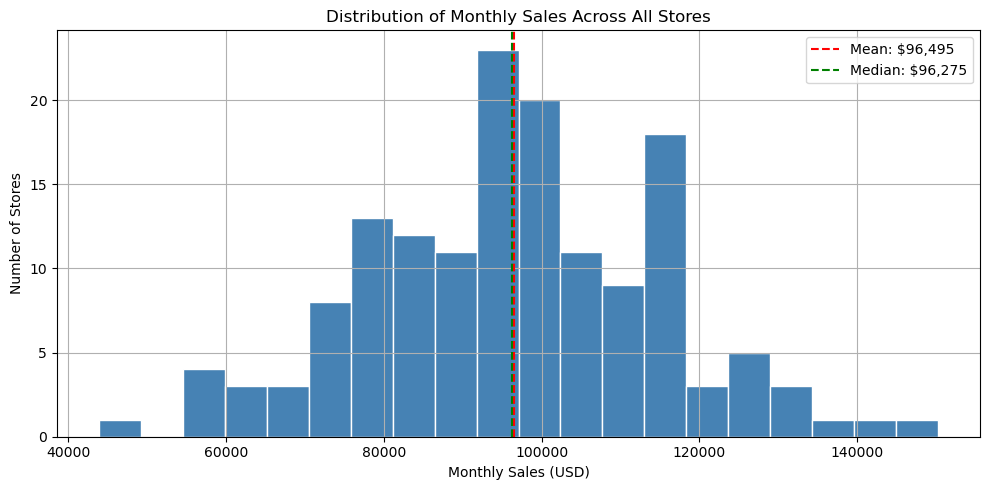

### WHAT: Monthly sales across 150 stores range from `~$45,000`to `~$152,000`, with a mean of`$96,495`and median of`$96,275`.

### This means: Sales are evenly distributed with no significant outlier distortion — group averages in future comparisons will be reliable and representative of actual store performance.

# D2:Which region and store type generates the highest average monthly sales?

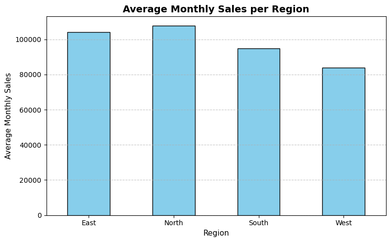

## The graph shows that the East and North regions exceeded 100,000 in average monthly sales, with the North region leading at around 110,000 and the East region at about 105,000. The South region followed with approximately 90,000, while the West region recorded the lowest average monthly sales at around 80,000.

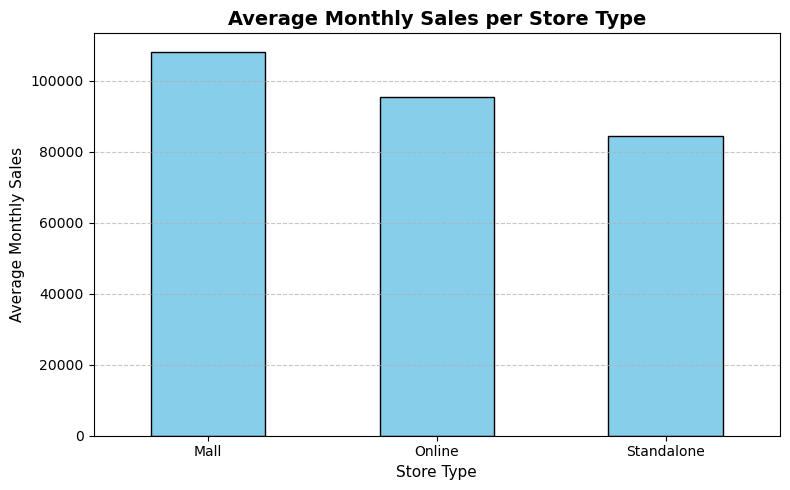

## This means that Mall stores had the highest average monthly sales across all regions, reaching around 110,000. Online stores followed with an average of about 90,000, while Standalone stores had the lowest average monthly sales at around 80,000.

# D3:What is the average return rate and profit margin per store type?

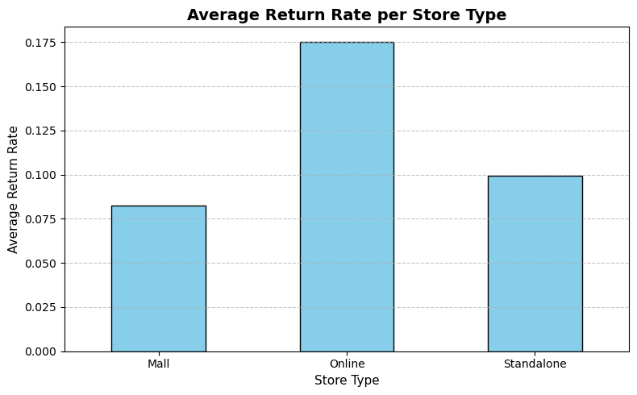

## This means that online stores had the highest average return rate at approximately 0.175, with a significantly higher rate compared to the other store types. Standalone stores followed with an average return rate of around 0.10, while mall stores had the lowest rate at approximately 0.08.

This suggests that further diagnostic analysis may be needed to identify the underlying causes.

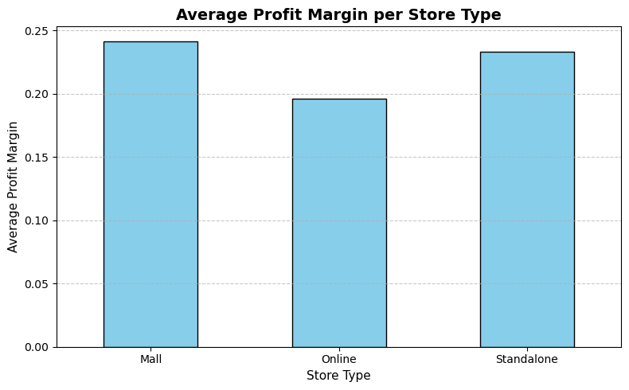

## This means that all store types had relatively similar profit margins. Mall stores recorded the highest average profit margin at around 0.24, followed closely by standalone stores, while online stores had the lowest average profit margin at approximately 0.19.

# Diagnostic — why is it like that?

## G1:Why does the top region outperform the others — is it footfall, transaction size, or employees?

```
=== Correlation with Monthly Sales ===
customer_footfall    0.900
marketing_spend      0.608
num_employees        0.289
avg_transaction     -0.096
Name: monthly_sales, dtype: float64
```

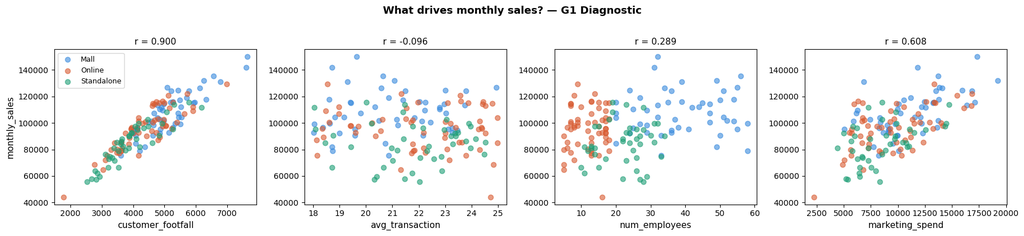

```
=== Driver Averages by Store Type ===
            customer_footfall  avg_transaction  num_employees  marketing_spend
store_type
Mall                  5181.98            20.97          38.71         11175.88
Online                4376.51            22.07          11.98          9540.16
Standalone            3900.00            21.82          22.29          8450.99
```

| store_type region | Mall | Online | Standalone |
| --- | --- | --- | --- |
| East | 13 | 13 | 8 |
| North | 9 | 11 | 14 |
| South | 11 | 18 | 7 |
| West | 16 | 17 | 13 |

```
=== Marketing Spend vs Sales by Region ===
        total_marketing_spend  avg_marketing_spend  avg_monthly_sales  \
region
North               363367.31             10687.27          107599.00
East                362804.43             10670.72          104053.33
South               350507.60              9736.32           94882.89
West                388749.49              8451.08           83964.00

        store_count
region
North            34
East             34
South            36
West             46

=== Marketing Efficiency by Region ===
        avg_marketing_spend  avg_monthly_sales  sales_per_marketing_dollar
region
North              10687.27          107599.00                       10.07
East               10670.72          104053.33                        9.75
South               9736.32           94882.89                        9.75
West                8451.08           83964.00                        9.94
```

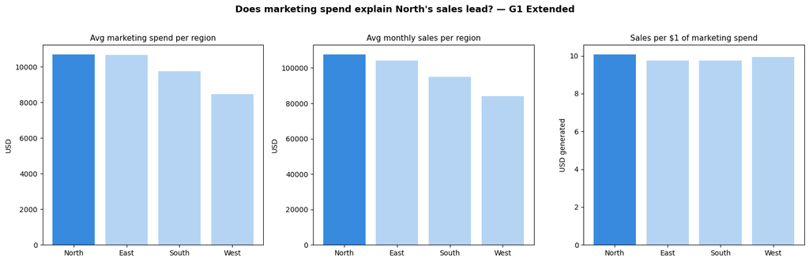

```
=== Avg Customer Footfall by Region ===
region
North    4937.0
East     4895.0
South    4368.0
West     4009.0
Name: customer_footfall, dtype: float64
```

# Insight

"North leads in both marketing spend 10,687/month and efficiency (10.07 return per 1 spent). However the efficiency gap between regions is narrow (10.07 vs 9.75), meaning North's sales lead is driven more by spend volume than by superior marketing effectiveness. At 10,000 average spend, a 0.32 efficiency gap translates to roughly $3,200 extra monthly sales per store — meaningful but not a structural advantage."

## G2: Is marketing spend actually paying off — or are high-spend stores underperforming?

```
=== Marketing Efficiency Distribution ===
mkt_efficiency
Average             104
Inefficient          23
Highly efficient     23
Name: count, dtype: int64

=== Efficiency by Store Type ===
mkt_efficiency  Inefficient  Average  Highly efficient
store_type
Mall                      7       37                 5
Online                    9       39                11
Standalone                7       28                 7

=== Full Efficiency Summary by Store Type ===
            avg_marketing_spend  avg_monthly_sales  avg_sales_per_dollar  \
store_type
Mall                   11175.88          108033.25                 10.35
Online                  9540.16           95492.17                 10.99
Standalone              8450.99           84443.79                 10.67

            inefficient_count  efficient_count
store_type
Mall                        7                5
Online                      9               11
Standalone                  7                7
```

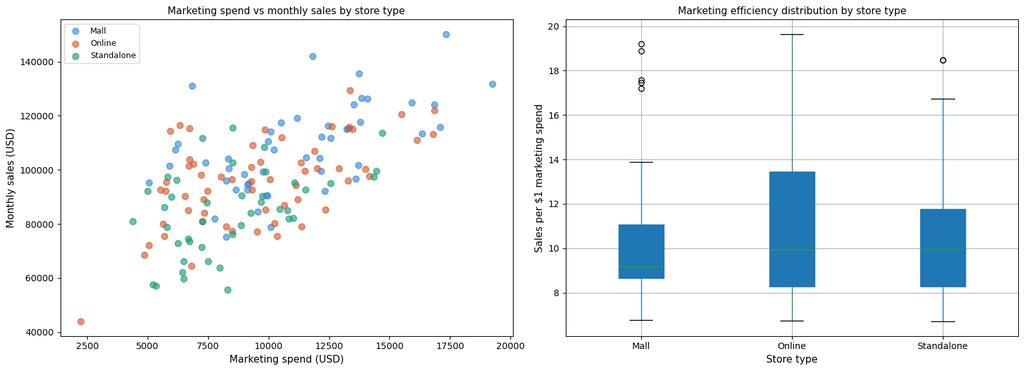

```
=== High Spend, Low Efficiency Stores (Top 10 worst) ===
 store_id region store_type  marketing_spend  monthly_sales  sales_per_mkt_dollar
      103  South Standalone          8310.93       55698.29                  6.70
        7  North     Online         16792.40      113129.52                  6.74
       36  North       Mall         17102.44      115755.17                  6.77
       12   East Standalone         14360.90       97381.87                  6.78
       87  South       Mall         19249.57      131775.90                  6.85
       16  North Standalone         14463.12       99563.82                  6.88
       42   East     Online         16130.52      111126.20                  6.89
      143   West     Online         12340.30       85188.72                  6.90
       50  South     Online         14153.59       97789.67                  6.91
       28  South       Mall         16350.12      113445.02                  6.94
```

## Is Marketing Spend Actually Paying Off?

### What the data shows

Overall, marketing spend has a moderate positive correlation with monthly sales (**r = 0.608**), suggesting it contributes to revenue but is not the dominant driver. Out of 150 stores:

- **104 stores (69%)** operate at average efficiency
- **23 stores (15%)** are highly efficient
- **23 stores (15%)** are inefficient

### Which store type converts marketing best?

| Store Type | Avg Marketing Spend | Avg Monthly Sales | Sales per $1 Spent |
| --- | --- | --- | --- |
| Online | $9,540 | $95,492 | $10.99 |
| Standalone | $8,451 | $84,444 | $10.67 |
| Mall | $11,176 | $108,033 | $10.35 |

Mall stores spend the most (**$11,176/month**) but deliver the lowest efficiency (`**\$10.35`per $1 spent**), suggesting diminishing returns at higher spending levels.

### The inefficiency problem

Online stores have the highest count of inefficient stores (**9 out of 59**), but also the highest count of highly efficient stores (**11 out of 59**). This makes Online a **high-variance channel** — it produces both the strongest and weakest performers.

Mall stores show the opposite pattern:

- High marketing spend
- Lower efficiency ceiling
- Fewer breakout performers

The 10 worst-performing stores span all three store types and all four regions, suggesting inefficiency is **not structural**. Instead, performance issues are likely driven by **store-specific execution problems** rather than weaknesses in the business model itself.

### Why it matters

Marketing spend is paying off overall, but returns are uneven across store formats.

The business is not getting consistent returns from Mall stores despite those stores receiving the largest budgets. Meanwhile, Online stores generate stronger returns on lower spend levels, although with higher variability and risk.

### This means...

Marketing investment is producing positive returns across all store types, but Mall stores remain the least efficient channel despite receiving the highest budgets.

This suggests the business may be:

- **Over-investing** in its most expensive format (Mall stores)
- **Under-investing** in its most efficient format (Online stores)

A more optimized allocation strategy could improve overall marketing ROI while reducing wasted spend.

## G3:Are high return rates killing profit margins — or is something else responsible?

```
<function matplotlib.pyplot.show(close=None, block=None)>
```

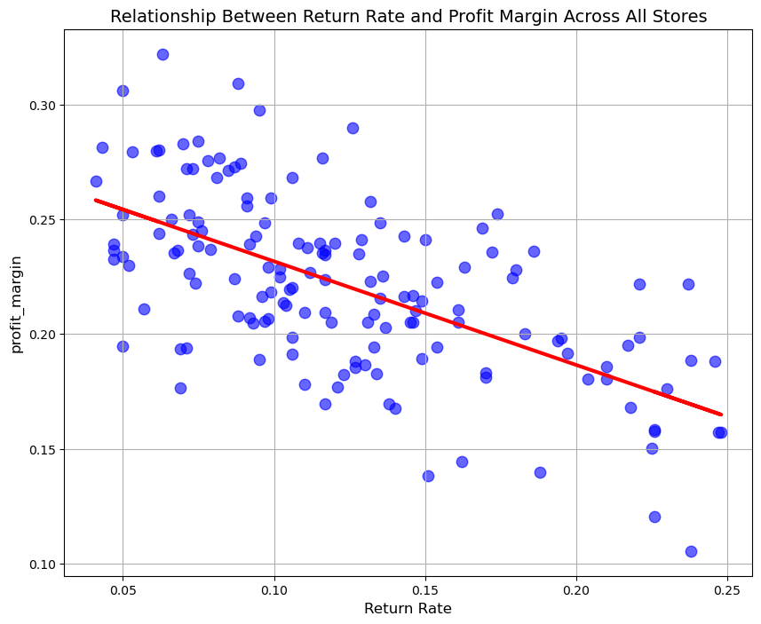

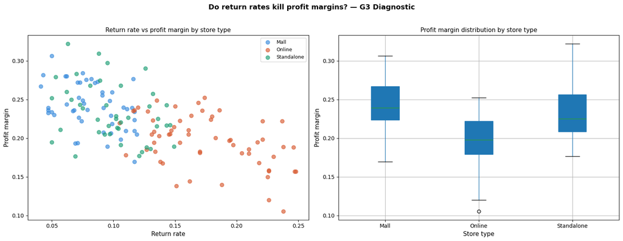

```
=== Correlation: Return Rate vs Profit Margin ===
r = -0.621

=== Return Rate vs Profit Margin by Store Type ===
            avg_return_rate  avg_profit_margin  max_return_rate  \
store_type
Mall                 0.0825             0.2409            0.119
Online               0.1750             0.1962            0.248
Standalone           0.0995             0.2328            0.149

            min_profit_margin
store_type
Mall                   0.1697
Online                 0.1054
Standalone             0.1765

=== Combined Pressure on Profit Margin ===
store_type
Online        0.2743
Standalone    0.2003
Mall          0.1857
Name: margin_pressure, dtype: float64
```

## Are High Return Rates Killing Profit Margins?

### What the data shows

Return rate has a moderate to strong negative correlation with profit margin (r = -0.621), meaning higher returns consistently compress margins across the dataset. This is not a weak relationship — return rate is one of the most significant margin drivers in this analysis.

### Return rate vs profit margin by store type

| Store Type | Avg Return Rate | Avg Profit Margin | Min Profit Margin |
| --- | --- | --- | --- |
| Mall | 8.25% | 24.09% | 16.97% |
| Standalone | 9.95% | 23.28% | 17.65% |
| Online | 17.50% | 19.62% | 10.54% |

Online stores carry more than double the return rate of Mall stores (17.5% vs 8.25%), which directly explains their lower average profit margin (19.62% vs 24.09%). The damage is real and measurable.

### Why Online margins survive despite high returns

Online stores have the highest combined margin pressure score (0.2743) from both return rate and marketing spend ratio combined. However, Online stores partially offset return damage through significantly lower marketing spend (`$ 9,540/month vs Mall's $ 11,176/month`). The marketing savings act as a buffer against the cost of high returns.

### The most dangerous stores

Stores facing BOTH high return rates AND high marketing spend ratios simultaneously face the worst combined margin pressure. These stores have no offsetting buffer — every return costs margin and every marketing dollar compounds the damage.

### This means...

Return rates are a significant and measurable margin killer (r = -0.621), but Online stores partially survive high returns through lower marketing spend — meaning the real threat to profitability is not return rate or marketing spend alone, but stores that suffer both pressures at the same time with no offsetting advantage.

# Phase 3 — Prescriptive Analysis

### Translating Findings into Business Recommendations

The following recommendations are derived directly from the descriptive and diagnostic findings across sales performance, marketing efficiency, and profit margin analysis. Each recommendation is backed by specific data points from the analysis.

## P1 — Where Should the Business Invest by Store Type?

### Recommendation Summary

| Store Type | Action | Reason |
| --- | --- | --- |
| Mall | Invest | Highest sales ($108,033) and margin (24.09%) |
| Online | Invest + Fix | Best marketing efficiency but high return risk |
| Standalone | Maintain | Balanced performance, no strong advantage |

### Mall Stores — Invest

Mall stores lead in average monthly sales (`$108,033`) and profit margin (24.09%), while also showing the lowest margin pressure score (0.1857). Although they use the highest marketing budget (`$11,176/month`), they still generate strong efficiency at `$10.35` per $1 spent. Mall stores offer the best balance of stability and profitability.

### Standalone Stores — Maintain

Standalone stores remain consistent but do not lead in any metric. With average sales of `$84,444`, profit margins of 23.28%, and marketing efficiency of `$10.67` per dollar, they provide stable but limited growth potential. Maintain current investment levels while prioritizing Mall and Online stores.

### This means...

The business should prioritize Mall stores for stable growth and Online stores for efficiency gains, while improving Online return rates before expansion.

## P2 — Where Should the $50,000 Marketing Budget Go?

### Recommended Allocation

| Channel | Allocation | Rationale |
| --- | --- | --- |
| Mall | `$30,000` | Highest sales and lowest margin risk |
| Online | `$15,000` | Best efficiency with higher upside |
| Standalone | `$5,000` | Maintain presence without scaling |

### Mall — `$30,000` (60%)

Mall stores generate `$10.35` in sales per `$1` of marketing spend and show the lowest margin pressure score (0.1857). A `$30,000` increase is expected to generate about $310,500 in additional sales. They also have fewer inefficient stores (7 of 49), reducing investment risk.

### Online — `$15,000` (30%)

Online stores deliver the highest marketing efficiency at `$10.99` per $1 spent, producing an estimated `$164,850`in additional sales from a`$15,000` increase. However, high return rates (17.5%) and more inefficient stores (9 of 59) make this a higher-risk channel. The allocation captures growth potential while limiting exposure.

### Standalone — `$5,000` (10%)

Standalone stores show stable but average performance with no major efficiency advantage. The $5,000 allocation is intended to maintain operations rather than drive expansion.

### North Region Priority

Mall and Online investments should prioritize North region stores. North leads in average sales (`$107,599`), marketing efficiency ($10.07 per dollar), and customer footfall (4,937 visitors monthly), making it the strongest region for incremental returns.

## About This Analysis

**Analyst:** CJ John A. Paulin **Date:** May 2026  
**Tools Used:** Python · Pandas · Matplotlib · Seaborn · Jupyter Notebook

### Connect With Me

- 📧 Email: cjjohnazurapaulin2022@gmail.com
- 💼 LinkedIn: linkedin.com/in/cjjohnpaulin
- 🐙 GitHub: github.com/cjjohnazurapaulin2022

*This analysis was independently conducted as part of a freelance data analyst portfolio.All analytical frameworks, insights, and recommendations are original work.*

© 2026 CJ John A Paulin . All rights reserved.